# Principal Component analysis

25.05.2018

### 1. Main problem

Sometimes you have a huge amount of variables. So, to make your data profitable you need to reduce number of variables saving without losing the precious information.

- Principal component analysis (PCA)
- Linear discriminant analysis (LDA)
- Multidimensional scaling (MDS)
- …

### 2. Data

I will use a dataset from [Huttenlocher, Vasilyeva, Cymerman, Levine 2002]. Authors analysed 46 pairs of mothers and children (aged from 47 to 59 months, mean age – 54). They recorded and trinscribed 2 hours from each child per day. During the study they collected number of noun phrases per utterance in mother speech to the number of noun phrases per utterance in child speech.

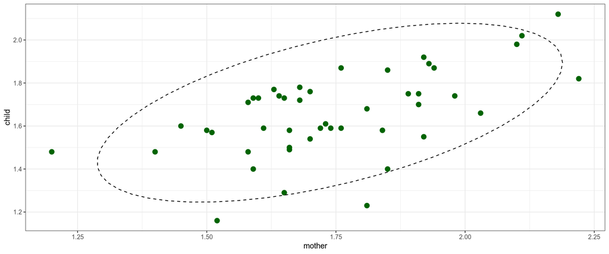

### 3. PCA

PCA is essentially a rotation of the coordinate axes, chosen such that each successful axis captures as much variance as possible. We can reduce 2 dementions to one using a regression:

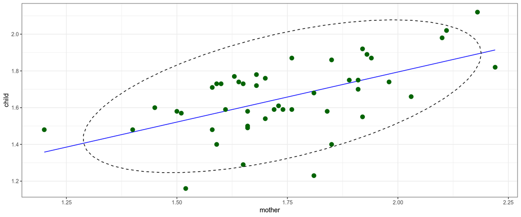

We used regression for predicting value of one variable by another variable.

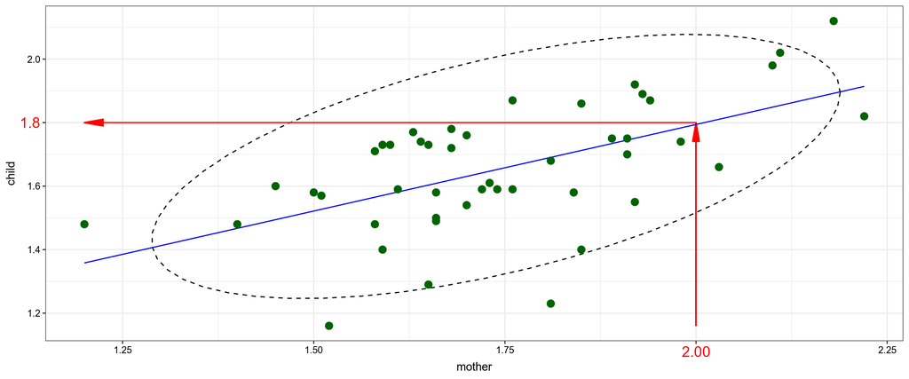

In PCA we change coordinate system and start predicting variables’ values using less variables.

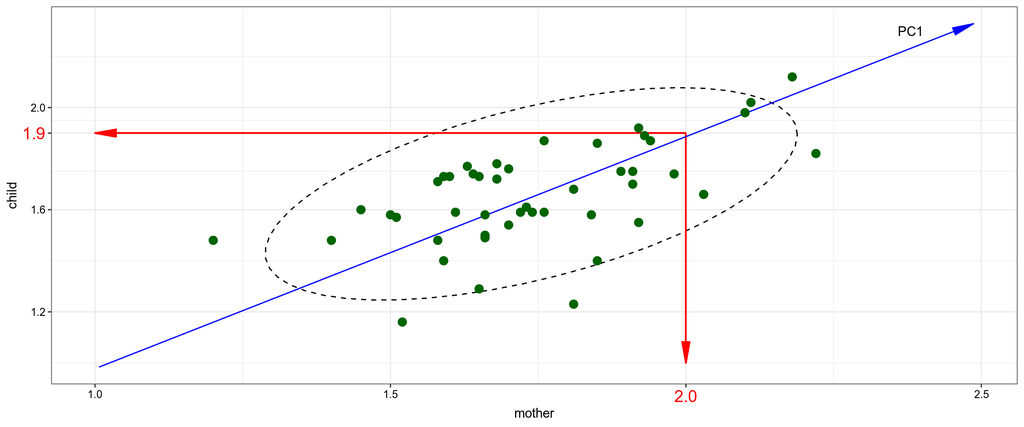

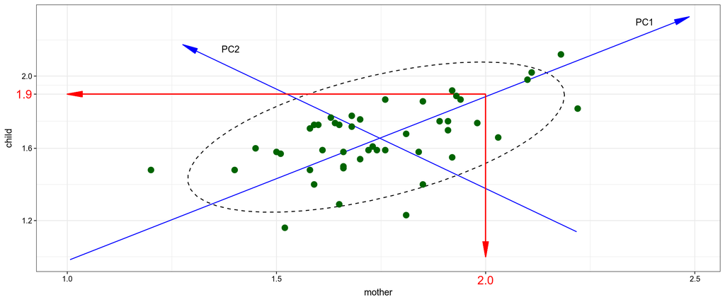

So the main point of PCA is that if cumulative proportion of explained variance is high we can drop some PCs. So, we need know the following things:

- What is the cumulative proportion of explained variance?

```r
summary(prcomp(df))
```

```
## Importance of components:
##                           PC1    PC2
## Standard deviation     0.2544 0.1316
## Proportion of Variance 0.7890 0.2110
## Cumulative Proportion  0.7890 1.0000
```

So, PC1 explains only 78.9% of the variance in our data.

- How PCs are rotated comparing to the old axes?

```r
df <- read.csv("../../data/Huttenlocher.csv")
prcomp(df)
```

```
## Standard deviations (1, .., p=2):
## [1] 0.2543899 0.1315688
##
## Rotation (n x k) = (2 x 2):
##              PC1        PC2
## child  0.6724959 -0.7401009
## mother 0.7401009  0.6724959
```

So the formula for the first component rotation is
$$PC1 = 0.6724959 \times child + 0.7401009 \times mother$$
The formula for the second component rotation is
$$PC2 = -0.7401009 \times child + 0.6724959 \times mother$$

From now we can change the axes:

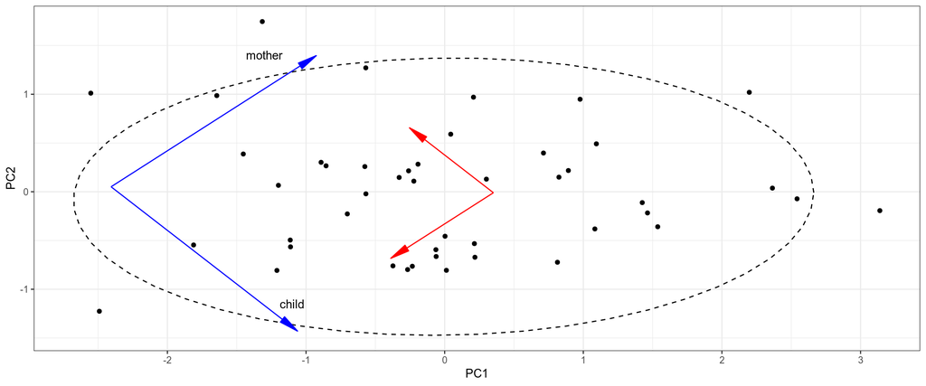

The `autoplot()` function from `ggfortify` package produces nearly the same graph:

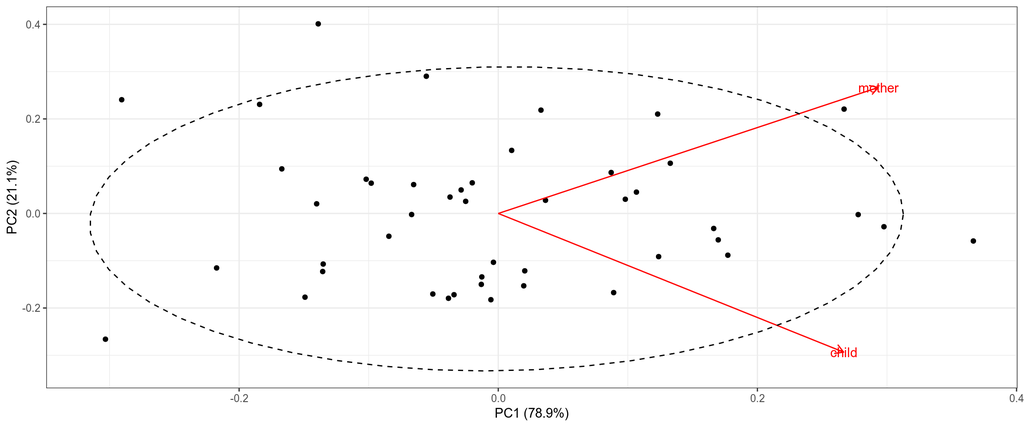

### [3D example](http://math-info.hse.ru/f/2015-16/ling-mag-quant/lecture-pca.html#%D0%A2%D1%80%D1%91%D1%85%D0%BC%D0%B5%D1%80%D0%BD%D1%8B%D0%B9%20%D0%BF%D1%80%D0%B8%D0%BC%D0%B5%D1%80) by Ilya Schurov

### Math behind the PCA

The main math technic that is used in PCA is finding eigenvalues and eigenvectors. This is a simple piece of math, but you need to have a good background in linear algebra (here is a [good course](https://www.youtube.com/playlist?list=PLZHQObOWTQDPD3MizzM2xVFitgF8hE_ab) with nice visualisations).

### R code example

We will use data from the novel by [P. Wodehouse “The Code of the Woosters”](https://en.wikipedia.org/wiki/The_Code_of_the_Woosters). I collected the frequency of some names according to different chapters:

```r
wodehouse <- read.csv("https://raw.githubusercontent.com/LingData2019/LingData/master/data/wodehouse_pca.csv")
wodehouse
```

| chapter | Harold | Gussie | Dahlia | Jeeves | Madeline | Oates | Spode | Stiffy | sir |
| --- | --- | --- | --- | --- | --- | --- | --- | --- | --- |
| Chapter 01 | 0.0000000 | 0.0024979 | 0.0012490 | 0.0041632 | 0.0010408 | 0.0000000 | 0.0000000 | 0.0002082 | 0.0041632 |
| Chapter 02 | 0.0000000 | 0.0018984 | 0.0011865 | 0.0090176 | 0.0016611 | 0.0000000 | 0.0011865 | 0.0004746 | 0.0099668 |
| Chapter 03 | 0.0000000 | 0.0045368 | 0.0008781 | 0.0014635 | 0.0035124 | 0.0000000 | 0.0058539 | 0.0001463 | 0.0021952 |
| Chapter 04 | 0.0030370 | 0.0026229 | 0.0001380 | 0.0013805 | 0.0011044 | 0.0015185 | 0.0017946 | 0.0030370 | 0.0013805 |
| Chapter 05 | 0.0002109 | 0.0029523 | 0.0014762 | 0.0082244 | 0.0000000 | 0.0002109 | 0.0040067 | 0.0014762 | 0.0113876 |
| Chapter 06 | 0.0000000 | 0.0051960 | 0.0000000 | 0.0014171 | 0.0033066 | 0.0000000 | 0.0075579 | 0.0014171 | 0.0004724 |
| Chapter 07 | 0.0000000 | 0.0040664 | 0.0016943 | 0.0052525 | 0.0005083 | 0.0000000 | 0.0108438 | 0.0015249 | 0.0047442 |
| Chapter 08 | 0.0024439 | 0.0006110 | 0.0001527 | 0.0054987 | 0.0000000 | 0.0004582 | 0.0004582 | 0.0070261 | 0.0070261 |
| Chapter 09 | 0.0022802 | 0.0007601 | 0.0002534 | 0.0007601 | 0.0007601 | 0.0022802 | 0.0000000 | 0.0035470 | 0.0030403 |
| Chapter 10 | 0.0000000 | 0.0034056 | 0.0000000 | 0.0027864 | 0.0018576 | 0.0003096 | 0.0040248 | 0.0027864 | 0.0049536 |
| Chapter 11 | 0.0000000 | 0.0057385 | 0.0007485 | 0.0064870 | 0.0014970 | 0.0022455 | 0.0027445 | 0.0002495 | 0.0129741 |
| Chapter 12 | 0.0000000 | 0.0040197 | 0.0062528 | 0.0107191 | 0.0000000 | 0.0008933 | 0.0013399 | 0.0000000 | 0.0093792 |
| Chapter 13 | 0.0021858 | 0.0007286 | 0.0014572 | 0.0076503 | 0.0000000 | 0.0018215 | 0.0010929 | 0.0014572 | 0.0094718 |
| Chapter 14 | 0.0000000 | 0.0005652 | 0.0022607 | 0.0067822 | 0.0007536 | 0.0033911 | 0.0022607 | 0.0011304 | 0.0160136 |

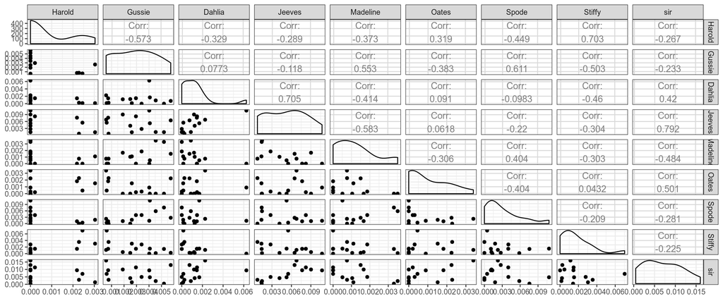

```r
library(GGally)
ggpairs(wodehouse[,-1])
```

```r
PCA <- prcomp(wodehouse[,-1])
PCA
```

```
## Standard deviations (1, .., p=9):
## [1] 0.0056971923 0.0034593165 0.0021253926 0.0018379315 0.0011487786
## [6] 0.0009801512 0.0007123842 0.0005034320 0.0002181423
##
## Rotation (n x k) = (9 x 9):
##                  PC1         PC2         PC3        PC4         PC5
## Harold    0.04446386 -0.26045490  0.07123814 -0.2007927  0.19032360
## Gussie    0.08779348  0.38160590 -0.15116503  0.2628203 -0.33907652
## Dahlia   -0.15615004  0.12382054 -0.44598913 -0.1200921  0.57733956
## Jeeves   -0.50150883  0.17557608 -0.44773479 -0.4588859 -0.25194436
## Madeline  0.11753413  0.11397729  0.02832850  0.3441355 -0.25226081
## Oates    -0.08429973 -0.11600713  0.21296940  0.2130548  0.52978937
## Spode     0.21798564  0.77103418  0.39697535 -0.3648273  0.21338990
## Stiffy    0.07986552 -0.33105390  0.36958846 -0.5731985 -0.24597480
## sir      -0.79975269  0.09921106  0.48203526  0.2003306 -0.04069356
##                  PC6         PC7         PC8         PC9
## Harold   -0.21673241  0.62957491 -0.34447525 -0.53532218
## Gussie   -0.78159891  0.13186661  0.10619326 -0.01443264
## Dahlia   -0.25790782 -0.50008339 -0.12601954 -0.28487803
## Jeeves    0.07393053  0.25634369 -0.25181765  0.32947429
## Madeline  0.13479280 -0.23614522 -0.84496615 -0.04925650
## Oates    -0.27686794  0.18859046 -0.22734885  0.66640912
## Spode     0.11194383  0.06916025 -0.06534478 -0.01343150
## Stiffy   -0.39980733 -0.40770488 -0.13773815  0.11544756
## sir      -0.05427500 -0.09007671  0.04324016 -0.25194682
```

How to interpret this:

What is the amount of the explained variance by each PC?

```r
summary(PCA)
```

```
## Importance of components:
##                             PC1      PC2      PC3      PC4      PC5
## Standard deviation     0.005697 0.003459 0.002125 0.001838 0.001149
## Proportion of Variance 0.585790 0.215970 0.081530 0.060960 0.023820
## Cumulative Proportion  0.585790 0.801760 0.883290 0.944250 0.968070
##                              PC6       PC7       PC8       PC9
## Standard deviation     0.0009802 0.0007124 0.0005034 0.0002181
## Proportion of Variance 0.0173400 0.0091600 0.0045700 0.0008600
## Cumulative Proportion  0.9854100 0.9945700 0.9991400 1.0000000
```

That means that first two components explain 80% of data variance.

```r
wodehouse_2 <- wodehouse[,-1]
rownames(wodehouse_2) <- wodehouse[, 1] # this is names
PCA <- prcomp(wodehouse_2)
```

Visualisation from package `ggfortify`:

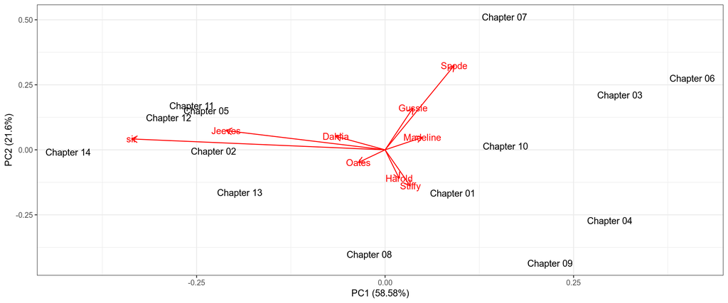

```r
library(ggfortify)
p1 <- autoplot(PCA,
               shape = FALSE,
               loadings = TRUE,
               label = TRUE,
               loadings.label = TRUE)
p1
```

Numbers on the graph are chapters, red lines are old coordinate axes. This kind of graphs are called **biplots**. Angle between old axes represent correlation between variables: cosine of this angle actually correspond to Pearson’s correlation coefficient.

### Lets transpose

```r
wodehouse <- read.csv("https://raw.githubusercontent.com/LingData2019/LingData/master/data/wodehouse_pca.csv")
w2 <- t(wodehouse[,-1])
colnames(w2) <- wodehouse$chapter
PCA <- prcomp(w2)
PCA
```

```
## Standard deviations (1, .., p=9):
## [1] 1.002254e-02 4.928666e-03 2.965444e-03 2.412650e-03 1.821397e-03
## [6] 1.035342e-03 9.133533e-04 2.802319e-04 4.540828e-19
##
## Rotation (n x k) = (14 x 9):
##                    PC1          PC2         PC3           PC4         PC5
## Chapter 01 -0.15263466 -0.001513558  0.16535932  0.0430770832  0.34268701
## Chapter 02 -0.37204371 -0.020028219  0.11657983  0.1312454455  0.23722864
## Chapter 03 -0.01813188  0.412179484  0.02161418 -0.1783410503  0.19161698
## Chapter 04  0.02441164  0.001669766 -0.22045109  0.1049453112  0.20181568
## Chapter 05 -0.39093914  0.116253799 -0.07536677  0.1317848140 -0.04688382
## Chapter 06  0.03752427  0.528501109 -0.10885786  0.0032358120  0.20930975
## Chapter 07 -0.14486142  0.598834670 -0.10087156  0.2998830378 -0.50483289
## Chapter 08 -0.19292324 -0.219991536 -0.53298331  0.5217074756  0.17624182
## Chapter 09 -0.02077421 -0.168481276 -0.31175833 -0.0329682455  0.04977489
## Chapter 10 -0.11809211  0.208994394 -0.26018514  0.0004857454  0.21505108
## Chapter 11 -0.39025974  0.102923750 -0.05776624 -0.4589155984  0.37693465
## Chapter 12 -0.36695065 -0.034963787  0.62648064  0.3208994523  0.03227427
## Chapter 13 -0.31376031 -0.158927691 -0.03649267  0.1348735652 -0.14102356
## Chapter 14 -0.47448653 -0.143999604 -0.19022859 -0.4751375701 -0.45297015
##                    PC6          PC7         PC8         PC9
## Chapter 01  0.02254613  0.049438050 -0.02672354 -0.63345991
## Chapter 02  0.65937984 -0.119509193  0.23291480  0.09273922
## Chapter 03  0.21796508  0.129372286 -0.65616036 -0.03178744
## Chapter 04 -0.27006099 -0.432382171 -0.26919800 -0.31204963
## Chapter 05 -0.05938171 -0.081486700 -0.42658102  0.52136899
## Chapter 06  0.11506359  0.037137727  0.36979229  0.13324975
## Chapter 07 -0.16031063 -0.131699715  0.15051934 -0.22423885
## Chapter 08 -0.02837714  0.316839378 -0.07858926 -0.07164758
## Chapter 09 -0.21208608  0.002688693  0.17909448  0.24436028
## Chapter 10 -0.01912647  0.325903487  0.15509613 -0.06738685
## Chapter 11 -0.41365980 -0.220505960  0.19045580  0.08852911
## Chapter 12 -0.37842825  0.272362516  0.02452666  0.04933785
## Chapter 13  0.17522179 -0.576996960  0.02100575 -0.08191341
## Chapter 14  0.10308361  0.303118096 -0.03204157 -0.25595046
```

```r
summary(PCA)
```

```
## Importance of components:
##                            PC1      PC2      PC3      PC4      PC5
## Standard deviation     0.01002 0.004929 0.002965 0.002413 0.001821
## Proportion of Variance 0.69440 0.167920 0.060790 0.040240 0.022930
## Cumulative Proportion  0.69440 0.862320 0.923110 0.963350 0.986280
##                             PC6       PC7       PC8       PC9
## Standard deviation     0.001035 0.0009134 0.0002802 4.541e-19
## Proportion of Variance 0.007410 0.0057700 0.0005400 0.000e+00
## Cumulative Proportion  0.993690 0.9994600 1.0000000 1.000e+00
```

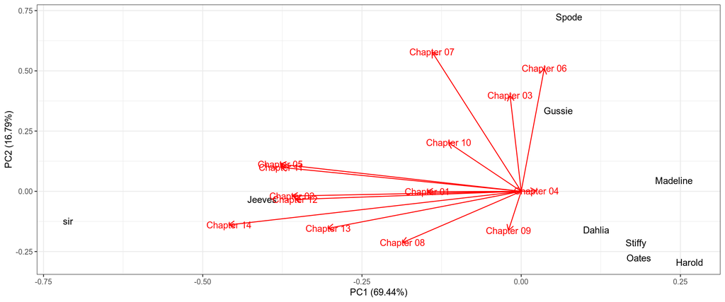

```r
p2 <- autoplot(PCA,
               shape = FALSE,
               loadings = TRUE,
               label = TRUE,
               loadings.label = TRUE)
p2
```

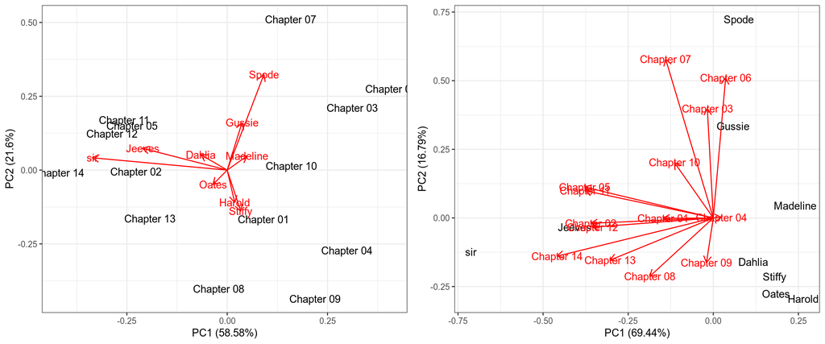

```r
library(gridExtra)
grid.arrange(p1, p2, ncol = 2)
```

### Summary:

- If the cumulative proportion of explained variance for some PCs is high, we can change coordinate system and start predicting variables’ values using less variables.
- We can even make a regresion or clusterisation model.
- PCA for categorical variables is called Multiple correspondence analysis (MCA)

### R functions

There are several functions for PCA, MCA and their visualisation.

- PCA: prcomp()
- PCA: princomp()
- PCA: FactoMineR::PCA()
- PCA: ade4::dudi.pca()
- PCA: amap::acp()
- PCA visualisation: ggfortify::autoplot
- MCA: FactoMineR::MCA()
- MCA: MASS::mca()
- MCA: ade::dudi.acm()
- MCA: ca::mjca()
- MCA: homals::homals()

### [Lab](https://docs.google.com/forms/d/e/1FAIpQLScviz1h3EuDEvAKXFujqdgwAKN1OEim_E1bRe0nej2Najyn9g/viewform)